# Hierarchical Cluster Analysis

K Siegmund

6/3/2020

## Libraries

```r
if(!require("ComplexHeatmap")){BiocManager::install("ComplexHeatmap")}
```

[output not shown]

```r
if(!require("matlab")){BiocManager::install("matlab")}
```

```r
library(ComplexHeatmap)
library(matlab)   # this library let's us use blue-red color spectrum for heatmap  (jet.colors)
library(matrixStats)

if(!require("dendextend")) install.packages("dendextend")
```

[output not shown]

```r
library(dendextend)
```

Load Prostate Cancer Data

```r
load("data/JBC 2012/jbcdat.rda")
```

## Dendrograms

I’m going to cluster the 100 most variable genes, because clustering the genes will show greater differences between the different cluster methods than clustering samples.

```r
rowscale <- function(x) {
      (x - rowMeans(x))/matrixStats::rowMads(x)
}

fmad <- matrixStats::rowMads(jbcdat$E)
rfilt <- rank(-fmad)
fidx <- which( rfilt <= 100)
```

```r
X <- rowscale(jbcdat$E)[fidx,]
fd <- as.dist(1-cor(t(X)))
```

**Average Linkage:**

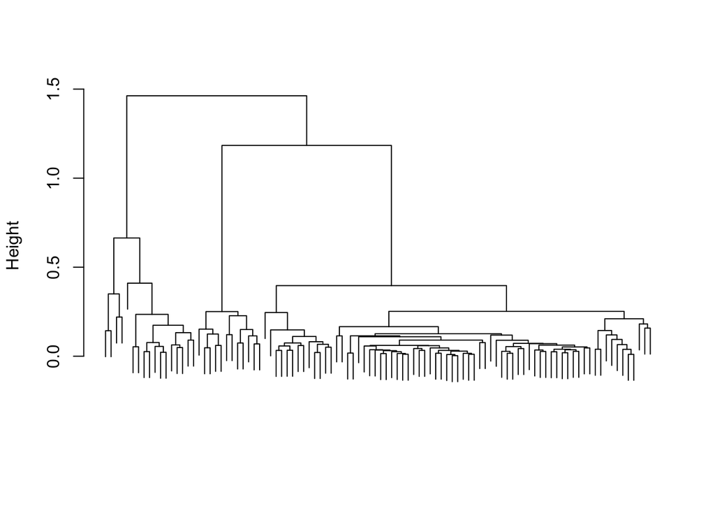

```r
hc <- hclust(fd, method = "average")
plot(hc,xlab=" ",main=" ",sub=" ",labels=FALSE)
```

**Single Linkage:**

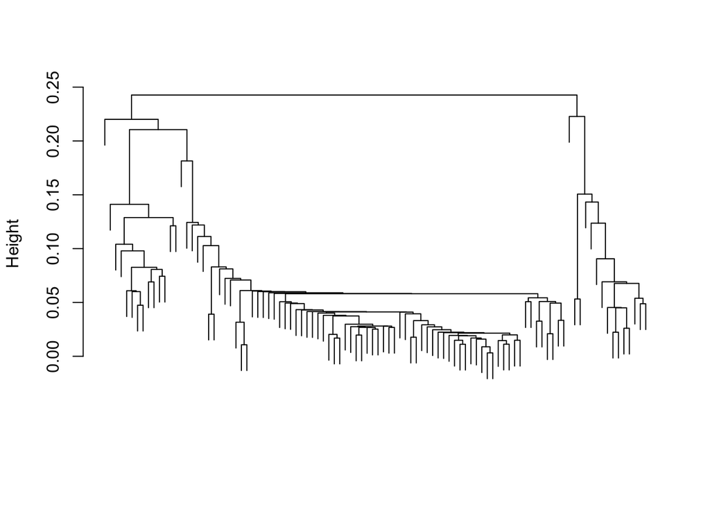

```r
hc <- hclust(fd, method = "single")
plot(hc,xlab=" ",main=" ",sub=" ",labels=FALSE)
```

**Complete Linkage:**

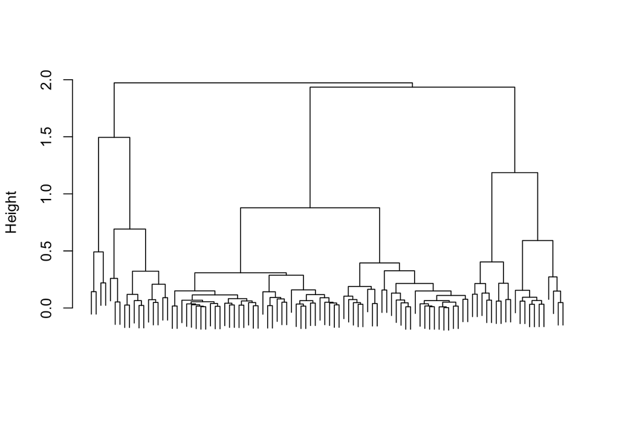

```r
hc <- hclust(fd, method = "complete")
plot(hc,xlab=" ",main=" ",sub=" ",labels=FALSE)
```

**Ward’s ESS:**

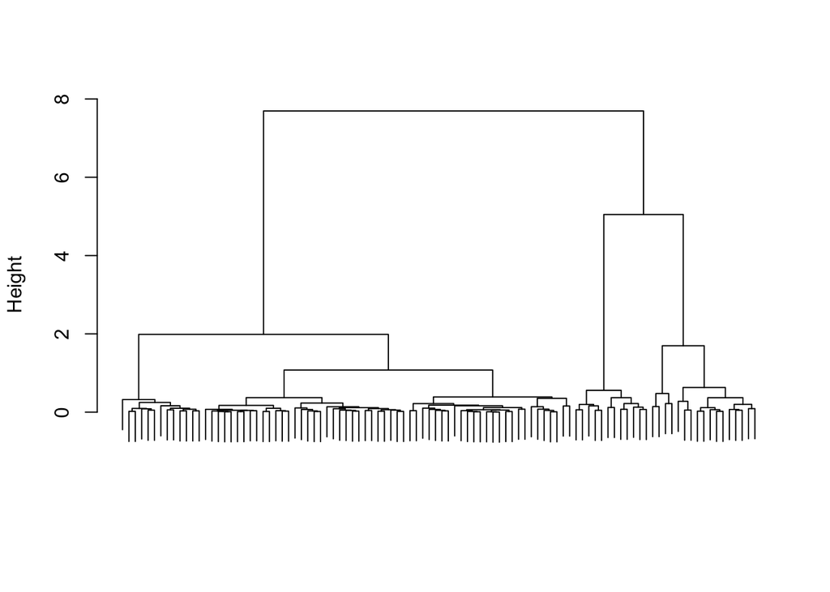

```r
hc <- hclust(fd, method = "ward.D2")
plot(hc,xlab=" ",main=" ",sub=" ",labels=FALSE)
```

## Complex Heatmap

There is a very flexible function in R for creating complex Heatmaps.

https://jokergoo.github.io/ComplexHeatmap-reference/book/introduction.html#general-design

```r
?Heatmap
```

To cluster both genes and samples, we will standardize the genes first, and then the samples. Then I’ll use 1-correlation as pairwise dissimilarity and Ward’s distance for the clustering criterion.

```r
fmad <- matrixStats::rowMads(jbcdat$E)
rfilt <- rank(-fmad)
fidx <- which( rfilt <= 500)
X <- rowscale(jbcdat$E)[fidx,]
scX <- scale(X,center=TRUE,scale=matrixStats::colMads(X))
```

First, I will create the color bars for annotating the samples.

```r
jbcdat$targets$treatment <- factor(jbcdat$targets$treatment,
                                   levels=c("siNS","siCBP","sip300"))

# column heatmap annotation
colha <- ComplexHeatmap::HeatmapAnnotation(df =
                       jbcdat$targets[,c("treatment","hour")],
                col = list(treatment = c(siNS = "pink",
                                         siCBP = "purple",
                                         sip300 = "orange"),
                                 hour = c('0hr' = "grey",
                                        '16hr' = "lightgreen")
                          ),
                which = "column")
```

Now call the heatmap.

**500 features, 1-Pearson dissimilarity**

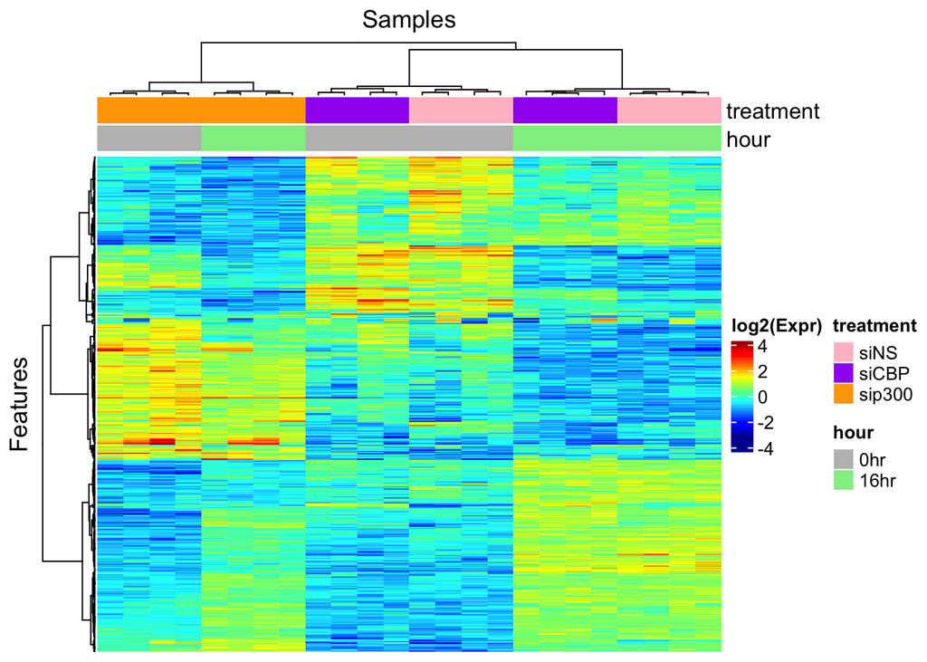

```r
ht <- ComplexHeatmap::Heatmap(scX, column_title = "Samples",
              row_title = "Features",
              name = "log2(Expr)",
              clustering_distance_rows = "pearson",
              clustering_method_rows = "ward.D2",
              clustering_distance_columns = "pearson",
              clustering_method_columns = "ward.D2",
              col = jet.colors(32),
              top_annotation = colha,
              show_column_names = FALSE,
              show_row_names = FALSE)

draw(ht)
```

In the above figure, the clustering is performed on the (gene- then sample- standardized) log2 expression data. Our sample labels show that the replicate samples cluster well. It also shows that the p300 knock-down cells are most different from the rest at both timepoints.

Comment: Since we standardized the columns, we get a very similar result using euclidean distance. They’d be identical if we’d standardized using standard deviation instead of median absolute deviation.

Let’s investigate using Euclidean distance for the (unstandardized) samples and changing the number of features.

**500 features, sample Euclidean dissimilarity**

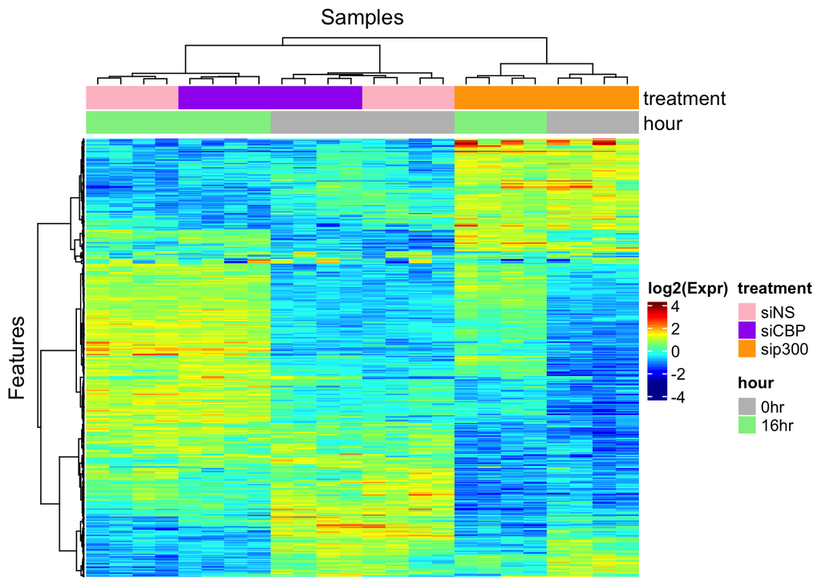

```r
fmad <- matrixStats::rowMads(jbcdat$E)
rfilt <- rank(-fmad)
fidx <- which( rfilt <= 500)
X <- rowscale(jbcdat$E)[fidx,]

ht <- ComplexHeatmap::Heatmap(X, column_title = "Samples",
              row_title = "Features",
              name = "log2(Expr)",
              clustering_distance_rows = "pearson",
              clustering_method_rows = "ward.D2",
              clustering_distance_columns = "euclidean",
              clustering_method_columns = "ward.D2",
              col = jet.colors(32),
              top_annotation = colha,
              show_column_names = FALSE,
              show_row_names = FALSE)

draw(ht)
```

It looks like there is no noticeable difference if we use Euclidean distance on the unstandardized samples. [Note: the genes are still standardized.] That suggests this result is robust to scaling of the samples. Now let’s try this on 300 features. Let’s go back to using correlation for the column similarities.

**500 randomly sampled features, 1-correlation dissimilarity**

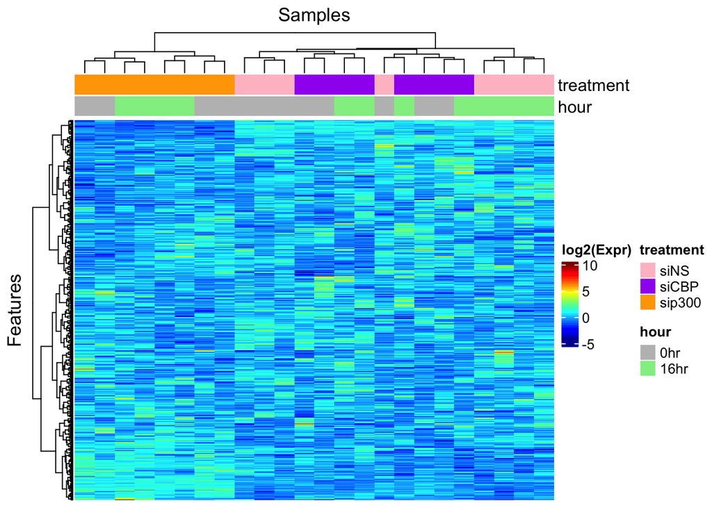

```r
set.seed(21)
idx <- sample(c(1:nrow(jbcdat$E)),500)
X <- rowscale(jbcdat$E)[idx,]
scX <- scale(X,center=TRUE,scale=matrixStats::colMads(X))

ht <- ComplexHeatmap::Heatmap(scX, column_title = "Samples",
              row_title = "Features",
              name = "log2(Expr)",
              clustering_distance_rows = "pearson",
              clustering_method_rows = "ward.D2",
              clustering_distance_columns = "pearson",
              clustering_method_columns = "ward.D2",
              col = jet.colors(32),
              top_annotation = colha,
              show_column_names = FALSE,
              show_row_names = FALSE)

draw(ht)
```

**300 (top mad) features, 1-correlation dissimilarity**

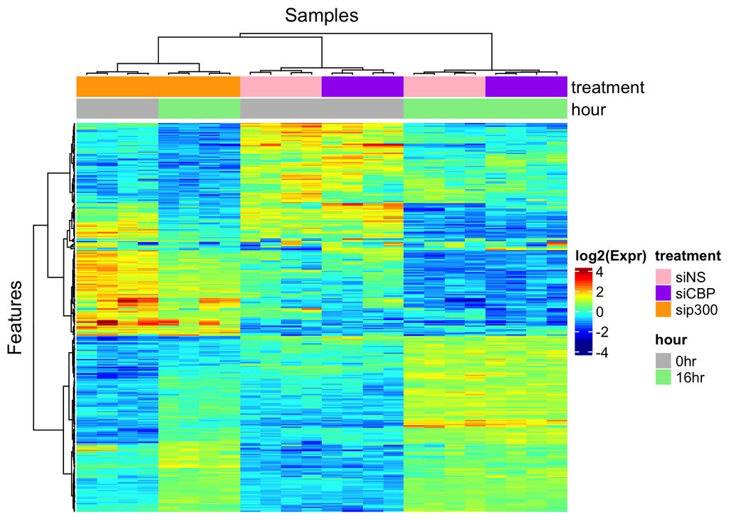

```r
fidx <- which(rfilt <= 300)
X <- rowscale(jbcdat$E)[fidx,]
scX <- scale(X,center=TRUE,scale=matrixStats::colMads(X))

ht <- ComplexHeatmap::Heatmap(scX, column_title = "Samples",
              row_title = "Features",
              name = "log2(Expr)",
              clustering_distance_rows = "pearson",
              clustering_method_rows = "ward.D2",
              clustering_distance_columns = "pearson",
              clustering_method_columns = "ward.D2",
              col = jet.colors(32),
              top_annotation = colha,
              show_column_names = FALSE,
              show_row_names = FALSE)

draw(ht)
```

The bottom 6 clusters look like they’re the same as when using 500 features, but the top 2 do not. Top clusters are unstable in hierarchical clustering algorithms.

**100 (top mad) features, 1-correlation dissimilarity**

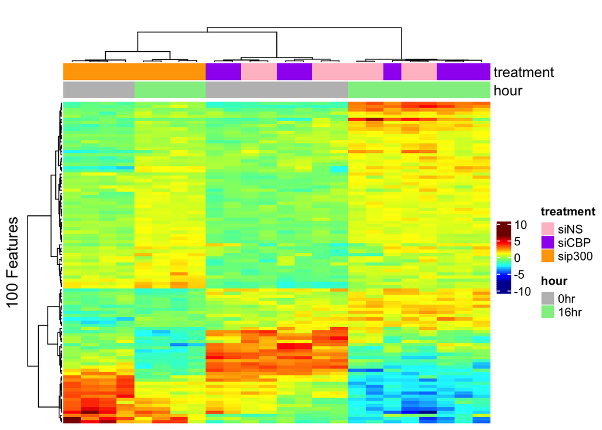

```r
fidx <- which(rfilt <= 100)
X <- rowscale(jbcdat$E)[fidx,]
scX <- scale(X,center=TRUE,scale=matrixStats::colMads(X))

ht <- ComplexHeatmap::Heatmap(scX, column_title = " ",
              row_title = "100 Features",
              name = " ",
              clustering_distance_rows = "pearson",
              clustering_method_rows = "ward.D2",
              clustering_distance_columns = "pearson",
              clustering_method_columns = "ward.D2",
              col = jet.colors(32),
              top_annotation = colha,
              show_column_names = FALSE,
              show_row_names = FALSE)

draw(ht)
```

What has changed now?

In the figure above we used pairwise correlation for the column similarities. What if we used euclidean distance instead?

**100 (top mad) features, sample Euclidean dissimilarity**

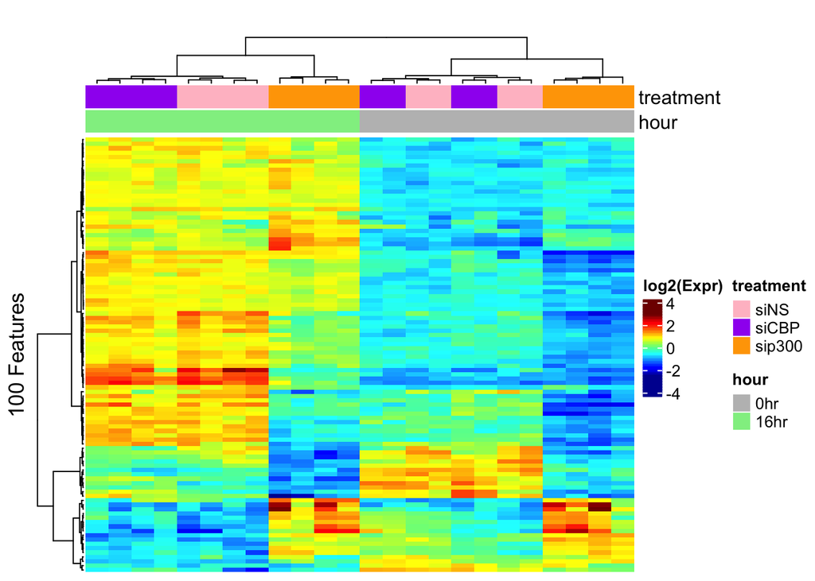

```r
fidx <- which(rfilt <= 100)
X <- rowscale(jbcdat$E)[fidx,]

hte <- ComplexHeatmap::Heatmap(X, column_title = " ",
              row_title = "100 Features",
              name = "log2(Expr)",
              clustering_distance_rows = "pearson",
              clustering_method_rows = "ward.D2",
              clustering_distance_columns = "euclidean",
              clustering_method_columns = "ward.D2",
              col = jet.colors(32),
              top_annotation = colha,
              show_column_names = FALSE,
              show_row_names = FALSE)

draw(hte)
```

So what is the correct figure?

## Extended Dendrograms

```r
fidx <- which(rfilt <= 500)
X <- rowscale(jbcdat$E)[fidx,]
scX <- scale(X,center=TRUE,scale=matrixStats::colMads(X))
```

```r
dend <- as.dist(1-cor(scX)) %>% # compute dissimilarity
        hclust(method = "ward.D2") %>% # Hierarchical clustering
        as.dendrogram # Turn the object into a dendrogram.
```

*Color the leafs:*

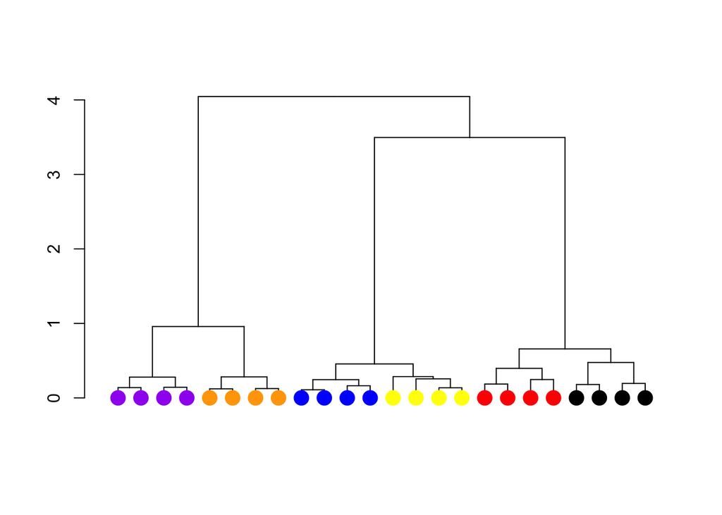

```r
cv <- c("black","yellow","red","blue","orange","purple","pink")
type_color <- cv[unclass(jbcdat$targets$type)][order.dendrogram(dend)]

dend %>% set("leaves_pch", c(16)) %>%  # node point type
  set("leaves_cex", 2) %>%  # node point size
  set("leaves_col", type_color) %>% #node point color
  set("labels", "") %>%
plot()
```

*Add color bars:*

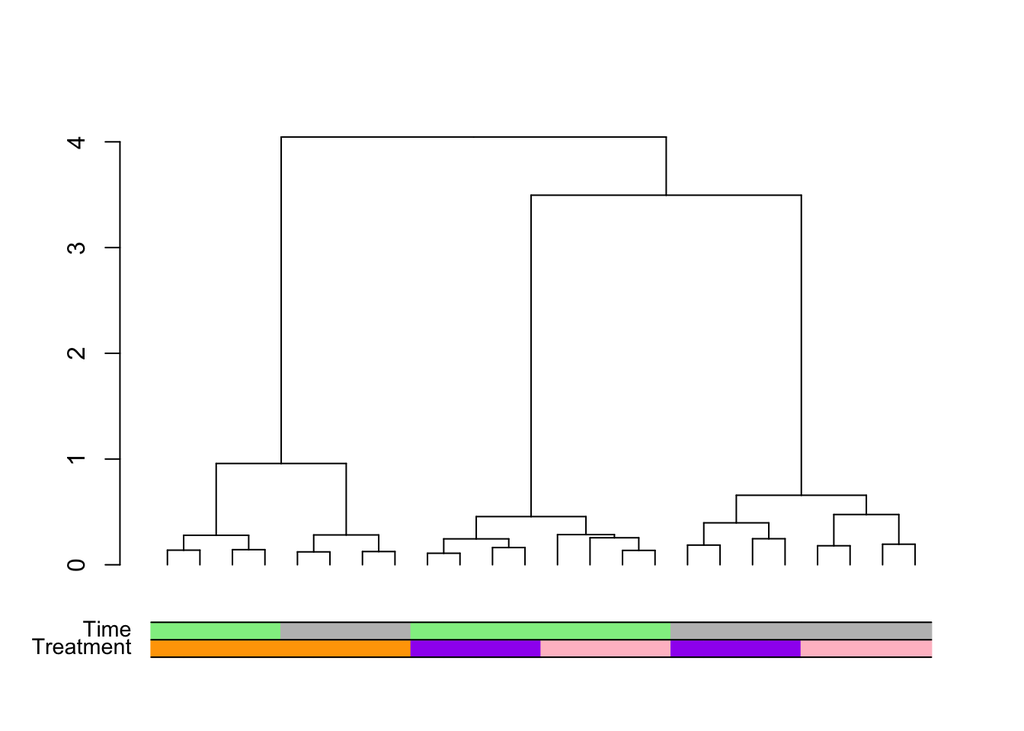

```r
trtcol  <- c("purple","pink","orange")
timecol <- c("grey","lightgreen")

trt_bar <- trtcol[as.numeric(factor(jbcdat$targets$treatment))]
trt_bar <- trt_bar[order.dendrogram(dend)]
time_bar <- timecol[as.numeric(factor(jbcdat$targets$hour))]
time_bar <- time_bar[order.dendrogram(dend)]
s_bar <- cbind(trt_bar,time_bar)

dend %>% set("labels", "") %>% plot
colored_bars(s_bar,rowLabels = c("Treatment","Time"))
```